# Assignment 2

Grace Levin, Sam Lewis, Naomi Robalino

10/28/2021

## Asignment 1

## 1. Research Question

How well does the increase in rent prices predict the number of people experiencing homelessness in the United States on the state level?

## 2. Prior Research

At first, we wanted to know the relationship between types of affordable housing and homelessness rates. However, according to Petry et. al. (2021) people at high risk of experiencing homelessness were likely to re-enter homelessness regardless of their housing type; they found those at high risk of experiencing homeslessness depended on their structural vulnerabilities. We instead decided to focus on larger scale forces such as the housing market and median rent prices in order to see how it affects the homelessness rate in the U.S. at the state level. Additionally, according to the U.S. Interagency Council on Homelessness (2021), households with higher levels of housing stability and access to housing affordability have a lower likelihood of entering homelessness, so we decided to look at the percent increase in rents as well.

## 3. Data

The sample set for this study is all states in the United States. The analysis will include the following variables:

Categorical:

- Region the U.S. state in is (U.S (American Community Survey 2019) [region]
- Majority party in the state legislature (“State Legislative Elections, 2021 - Ballotpedia” 2021) [party_stateleg]

Continuous:

- Number of people experience poverty (American Community Survey 2019) [povertyE]
- Median gross rent (American Community Survey 2019) [median_rent]
- Percent Increase in rents since 2001 (American Community Survey 2019) [perincrease_rent]
- Total number of people experiencing homelessness (HUD 2018 Annual Homelessness Assessment Report) [homelessness]
- Total number of beds available in homeless shelters (PIT and HIC Data Since 2007, 2021) [bed_counts_per_state]

## 4. References

“National And State Housing Fact Sheets & Data”. 2019. Center On Budget And Policy Priorities. https://www.cbpp.org/research/housing/national-and-state-housing-fact-sheets-data.

Petry, Laura, Chyna Hill, Phebe Vayanos, Eric Rice, Hsun-Ta Hsu, and Matthew Morton. “Associations Between the Vulnerability Index-Service Prioritization Decision Assistance Tool and Returns to Homelessness Among Single Adults in the United States.” Cityscape 23, no. 2 (2021): 293–324. https://www.jstor.org/stable/27039964.

“PIT And HIC Data Since 2007”. 2021. Hudexchange.Info. https://www.hudexchange.info/resource/3031/pit-and-hic-data-since-2007/.

“State Legislative Elections, 2021 - Ballotpedia”. 2021. Ballotpedia. https://ballotpedia.org/State_legislative_elections,_2021.

2021. Usich.Gov. https://www.usich.gov/resources/uploads/asset_library/Housing-Affordability-and-Stablility-Brief.pdf.

United States Census Bureau. American Community Survey, 5-year estimates. 2019.

## 5. Load Packages

First we loaded the following packages:

```r
library(osmextract)
library(tidyverse)
library(sf)
library(ggthemes)
library(ggspatial)
library(tigris)
library(wesanderson)
library(tidytransit)
library(tidycensus)
library(dplyr)
library(stars)
library(readxl)
library(knitr)
library(gridExtra)
```

## 6. Load Data

Then, we imported the American Community Census data recorded in 2019 (from the year 2015-2019) and the census data

```r
census_api_key("32af35a06c38b3b5eaf52448f34555621ee04370", install=TRUE, overwrite = TRUE)
```

```
## [1] "32af35a06c38b3b5eaf52448f34555621ee04370"
```

```r
readRenviron("~/.Renviron")

acs_vars <- load_variables(2019, "acs1")
```

Then we loaded the state poverty levels from the 2019 ACS data.

```r
state_poverty <- get_acs(geography = "state",
                         year = 2019,
                          output = "wide",
                          variables = c(poverty = 'B05010_002', pop = 'B01003_001'))
```

Then we loaded the state population from the 2019 ACS data.

```r
state_pop <- get_acs(geography = "state",
                         year = 2019,
                          output = "wide",
                          variables = c(population = 'B01003_001'))
```

Then, we loaded state housing facts.

```r
state_housing <- read_csv(file = 'statehousingfacts.csv')
```

Then we loaded bed counts per state.

```r
state_shelter <- read_csv(file = 'state_bed.csv') %>%
  rename (bed_counts_per_state = beds)
```

## 7. Join Data

Lastly, we joined the state poverty, state housing, state shelter.

```r
data <- left_join(state_poverty, state_housing, by = 'NAME') %>%
  left_join(state_shelter)

data <- select(data, -popM, -povertyM)

knitr::kable(data)
```

| GEOID | NAME | povertyE | popE | region | party_stateleg | median_rent | perincrease_rent | homelessness | bed_counts_per_state |
| --- | --- | --- | --- | --- | --- | --- | --- | --- | --- |
| 01 | Alabama | 235001 | 4876250 | South | Republican | 790 | 0.16 | 3430 | 2913 |
| 02 | Alaska | 24455 | 737068 | West | Republican | 1180 | 0.09 | 2020 | 1885 |
| 04 | Arizona | 318685 | 7050299 | West | Republican | 1040 | 0.12 | 9870 | 6079 |
| 05 | Arkansas | 149836 | 2999370 | South | Republican | 730 | 0.01 | 2710 | 1686 |
| 06 | California | 1516251 | 39283497 | West | Democrat | 1520 | 0.30 | 129970 | 53265 |
| 08 | Colorado | 144208 | 5610349 | West | Democrat | 1290 | 0.24 | 10860 | 8274 |
| 10 | Delaware | 32367 | 957248 | Northeast | Democrat | 1110 | 0.16 | 1080 | 1026 |
| 11 | District of Columbia | 27509 | 692683 | Northeast | Democrat | 1520 | 0.59 | 6900 | 6687 |
| 09 | Connecticut | 90864 | 3575074 | Northeast | Democrat | 1170 | 0.13 | 3980 | NA |
| 12 | Florida | 771399 | 20901636 | South | Florida | 1180 | 0.19 | 31030 | 17793 |
| 13 | Georgia | 492305 | 10403847 | South | Republican | 1010 | 0.04 | 9500 | 7413 |
| 16 | Idaho | 64263 | 1717750 | West | Republican | 850 | 0.10 | 2010 | 1577 |
| 15 | Hawaii | 32345 | 1422094 | West | Republican | 1610 | 0.40 | 6530 | 3384 |
| 17 | Illinois | 460063 | 12770631 | Midwest | Democrat | 1000 | 0.05 | 10640 | 10233 |
| 18 | Indiana | 262429 | 6665703 | Midwest | Republican | 820 | 0.02 | 5260 | 5821 |
| 19 | Iowa | 92099 | 3139508 | Midwest | Republican | 780 | 0.03 | 2750 | 2566 |
| 20 | Kansas | 98079 | 2910652 | Midwest | Republican | 840 | 0.06 | 2220 | 2813 |
| 21 | Kentucky | 208474 | 4449052 | South | Republican | 780 | 0.13 | 3690 | 3322 |
| 22 | Louisiana | 272808 | 4664362 | South | Republican | 850 | 0.10 | 3060 | 2580 |
| 23 | Maine | 34146 | 1335492 | Northeast | Democrat | 840 | 0.09 | 2520 | 2348 |
| 24 | Maryland | 148190 | 6018848 | South | Democrat | 1370 | 0.31 | 7140 | 5221 |
| 25 | Massachusetts | 165614 | 6850553 | Northeast | Democrat | 1300 | 0.17 | 20070 | 17528 |
| 26 | Michigan | 399962 | 9965265 | Midwest | Republican | 860 | 0.03 | 8350 | 8964 |
| 27 | Minnesota | 143952 | 5563378 | Midwest | Republican | 970 | 0.07 | 7240 | 6730 |
| 28 | Mississippi | 183922 | 2984418 | South | Republican | 780 | 0.10 | 1350 | 962 |
| 29 | Missouri | 232303 | 6104910 | Midwest | Republican | 830 | 0.07 | 5880 | 5763 |
| 30 | Montana | 31822 | 1050649 | West | Republican | 810 | 0.17 | 1410 | 1351 |
| 31 | Nebraska | 59908 | 1914571 | West | Republican | 830 | 0.08 | 2420 | 2764 |
| 32 | Nevada | 113492 | 2972382 | West | Democrat | 1110 | 0.04 | 7540 | 3153 |
| 33 | New Hampshire | 21524 | 1348124 | Northeast | Republican | 1090 | 0.08 | 1450 | 1574 |
| 34 | New Jersey | 258728 | 8878503 | Northeast | Democrat | 1340 | 0.17 | 9400 | 7178 |
| 35 | New Mexico | 119966 | 2092454 | West | Democrat | 830 | 0.11 | 2550 | 2379 |
| 36 | New York | 743524 | 19572319 | Northeast | Democrat | 1270 | 0.26 | 91900 | 88955 |
| 37 | North Carolina | 442335 | 10264876 | South | Republican | 900 | 0.06 | 9270 | 7928 |
| 38 | North Dakota | 17913 | 756717 | Midwest | Republican | 810 | 0.27 | 540 | 757 |
| 39 | Ohio | 471569 | 11655397 | Midwest | Republican | 800 | 0.01 | 10250 | 9253 |
| 40 | Oklahoma | 184975 | 3932870 | South | Republican | 810 | 0.10 | 3870 | 3101 |
| 41 | Oregon | 130226 | 4129803 | West | Democrat | 1130 | 0.23 | 14480 | 5957 |
| 42 | Pennsylvania | 427555 | 12791530 | Northeast | Republican | 930 | 0.15 | 13510 | 12789 |
| 44 | Rhode Island | 32769 | 1057231 | Northeast | Democrat | 1000 | 0.15 | 1100 | 993 |
| 45 | South Carolina | 219937 | 5020806 | South | Republican | 890 | 0.11 | 3930 | 3067 |
| 46 | South Dakota | 32252 | 870638 | Midwest | Republican | 730 | 0.08 | 1160 | 1215 |
| 47 | Tennessee | 298249 | 6709356 | South | Republican | 860 | 0.11 | 7880 | 5060 |
| 48 | Texas | 1420032 | 28260856 | South | Republican | 1050 | 0.17 | 25310 | 18141 |
| 50 | Vermont | 13452 | 624313 | Northeast | Democrat | 970 | 0.16 | 1290 | 823 |
| 49 | Utah | 93811 | 3096848 | West | Republican | 1040 | 0.18 | 2880 | 2865 |
| 51 | Virginia | 234780 | 8454463 | South | Democrat | 1220 | 0.21 | 5980 | 4973 |
| 53 | Washington | 203579 | 7404107 | West | Democrat | 1320 | 0.32 | 22300 | 14817 |
| 54 | West Virginia | 77653 | 1817305 | South | Republican | 740 | 0.21 | 1240 | 1480 |
| 55 | Wisconsin | 174427 | 5790716 | Midwest | Republican | 850 | 0.01 | 4910 | 4341 |
| 56 | Wyoming | 15236 | 581024 | West | Republican | 820 | 0.23 | 640 | 804 |
| 72 | Puerto Rico | 352372 | 3318447 | NA | NA | NA | NA | NA | NA |

```r
poverty_t_test <- t.test(data$povertyE)
popE_t_test <- t.test(data$popE)
median_rent_t_test <- t.test(data$median_rent)
perincrease_rent_t_test <- t.test(data$perincrease_rent)
homelessness_t_test <- t.test(data$homelessness)
bed_counts_per_state_t_test <- t.test(data$bed_counts_per_state)

poverty_quartiles <- quantile(data$povertyE, na.rm = TRUE)
popE_quartiles <- quantile(data$popE, na.rm = TRUE)
median_rent_quartiles <- quantile(data$median_rent, na.rm = TRUE)
perincrease_rent_quartiles <- quantile(data$perincrease_rent, na.rm = TRUE)
homelessness_quartiles <- quantile(data$homelessness, na.rm = TRUE)
bed_counts_per_state_quartiles <- quantile(data$bed_counts_per_state, na.rm = TRUE)


poverty_st_dev <- sd(data$povertyE, na.rm = TRUE)
popE_st_dev <- sd(data$popE, na.rm = TRUE)
median_rent_st_dev <- sd(data$median_rent, na.rm = TRUE)
perincrease_rent_st_dev <- sd(data$perincrease_rent, na.rm = TRUE)
homelessness_st_dev <- sd(data$homelessness, na.rm = TRUE)
bed_counts_per_state_st_dev <- sd(data$bed_counts_per_state, na.rm = TRUE)
```

```r
poverty_hist <- ggplot(data) +
  geom_histogram(aes(x = povertyE),
                 bins = 30)

popE_hist <- ggplot(data) +
  geom_histogram(aes(x = popE),
                 bins = 30)

median_rent_hist <- ggplot(data) +
  geom_histogram(aes(x = median_rent),
                 bins = 30)

perincrease_rent_hist <- ggplot(data) +
  geom_histogram(aes(x = perincrease_rent),
                 bins = 30)

homelessness_hist <- ggplot(data) +
  geom_histogram(aes(x = homelessness),
                 bins = 30)

bed_counts_per_state_hist <- ggplot(data) +
  geom_histogram(aes(x = bed_counts_per_state),
                 bins = 30)
```

## Poverty

```r
poverty_t_test
```

```
##
##  One Sample t-test
##
## data:  data$povertyE
## t = 5.8649, df = 51, p-value = 3.337e-07
## alternative hypothesis: true mean is not equal to 0
## 95 percent confidence interval:
##  161812.9 330249.2
## sample estimates:
## mean of x
##  246031.1
```

```r
poverty_st_dev
```

```
## [1] 302505.9
```

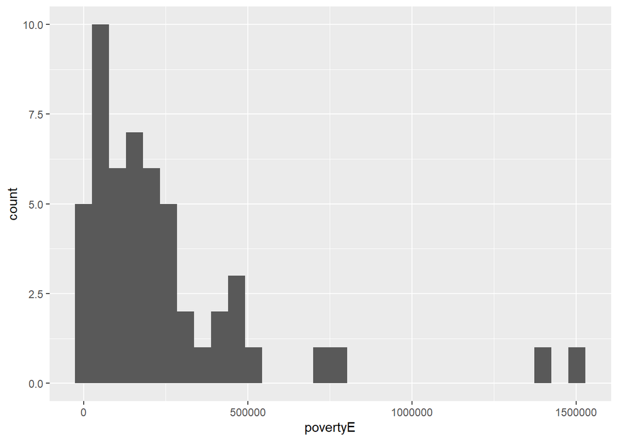

```r
poverty_hist
```

## Population

```r
popE_t_test
```

```
##
##  One Sample t-test
##
## data:  data$popE
## t = 6.3027, df = 51, p-value = 6.864e-08
## alternative hypothesis: true mean is not equal to 0
## 95 percent confidence interval:
##  4298724 8317285
## sample estimates:
## mean of x
##   6308005
```

```r
popE_st_dev
```

```
## [1] 7217198
```

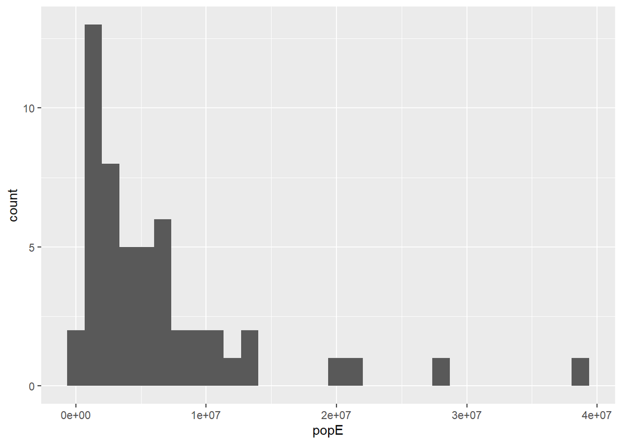

```r
popE_hist
```

## Median Rent

```r
median_rent_t_test
```

```
##
##  One Sample t-test
##
## data:  data$median_rent
## t = 31.418, df = 50, p-value < 2.2e-16
## alternative hypothesis: true mean is not equal to 0
## 95 percent confidence interval:
##   939.1909 1067.4758
## sample estimates:
## mean of x
##  1003.333
```

```r
median_rent_st_dev
```

```
## [1] 228.0585
```

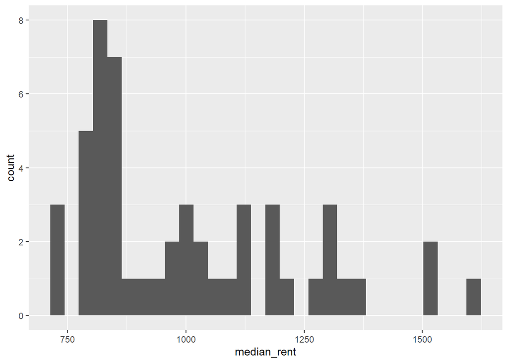

```r
median_rent_hist
```

## Percent Increase in Rent

```r
perincrease_rent_t_test
```

```
##
##  One Sample t-test
##
## data:  data$perincrease_rent
## t = 9.5194, df = 50, p-value = 8.21e-13
## alternative hypothesis: true mean is not equal to 0
## 95 percent confidence interval:
##  0.1149470 0.1764255
## sample estimates:
## mean of x
## 0.1456863
```

```r
perincrease_rent_st_dev
```

```
## [1] 0.1092933
```

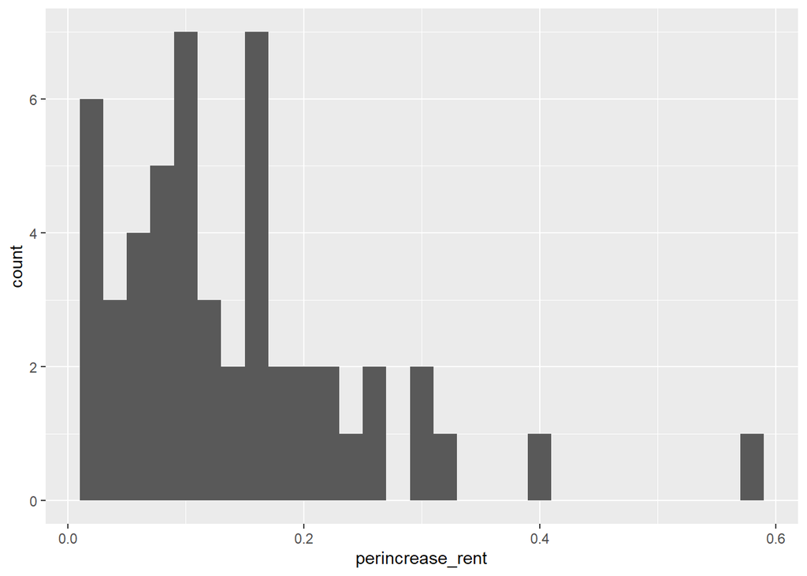

```r
perincrease_rent_hist
```

```r
homelessness_t_test
```

```
##
##  One Sample t-test
##
## data:  data$homelessness
## t = 3.5189, df = 50, p-value = 0.0009334
## alternative hypothesis: true mean is not equal to 0
## 95 percent confidence interval:
##   4605.758 16855.811
## sample estimates:
## mean of x
##  10730.78
```

```r
homelessness_st_dev
```

```
## [1] 21777.52
```

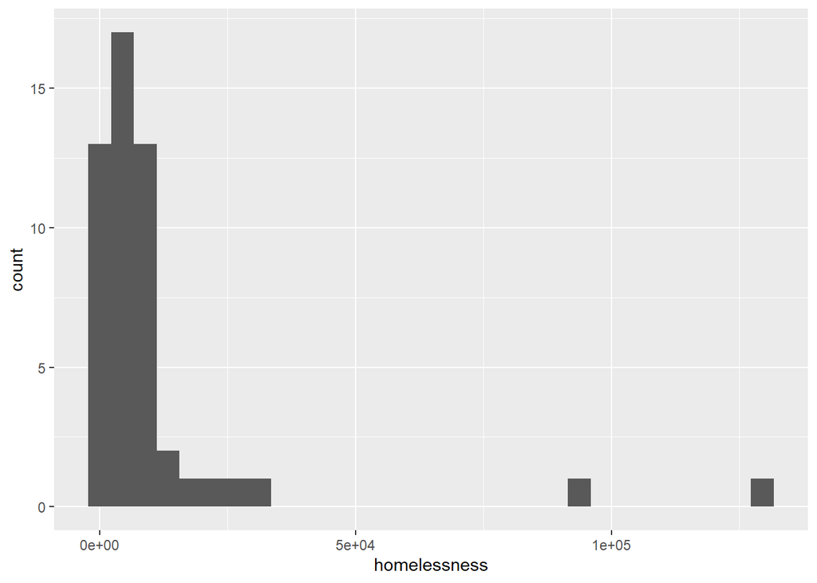

```r
homelessness_hist
```

## Homeless beds

```r
bed_counts_per_state_t_test
```

```
##
##  One Sample t-test
##
## data:  data$bed_counts_per_state
## t = 3.8922, df = 49, p-value = 0.0003002
## alternative hypothesis: true mean is not equal to 0
## 95 percent confidence interval:
##   3797.459 11904.581
## sample estimates:
## mean of x
##   7851.02
```

```r
bed_counts_per_state_st_dev
```

```
## [1] 14263.22
```

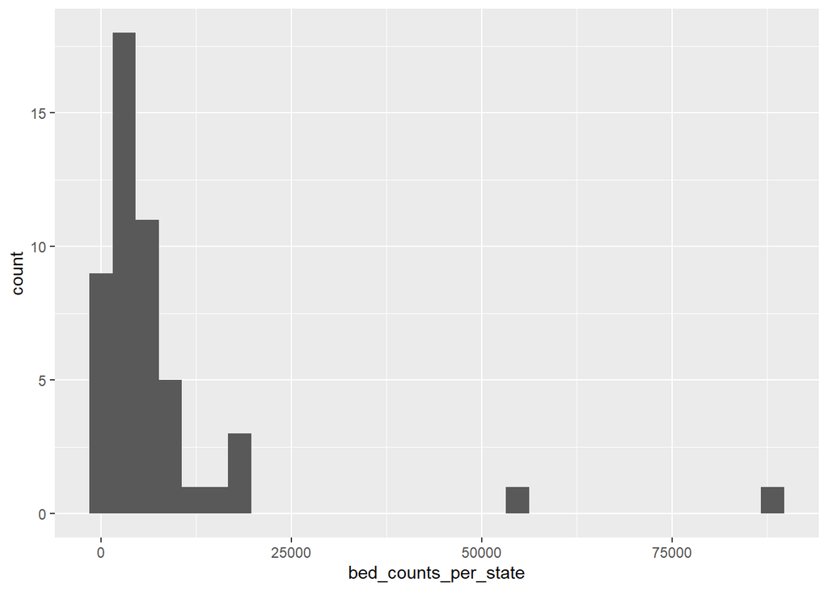

```r
bed_counts_per_state_hist
```